# Simple Linear Regression in R.

1. Introduction to Simple Linear Regression.
2. Assumptions for a Simple Linear Regression.
3. Estimating and Interpreting Parameters.

# Introduction to Simple Linear Regression.

**The Basics:**

- Simple linear regression model is one instance of the general linear model.
- A simple linear regression model has two variables
  - The response variable (dependent), generally denoted as $y$, and is numeric.
  - A single independent variable denoted at $x$ and is numeric (typically on the continuous scale).
- Each sampling unit in a linear model contains these two numeric variables $$(x, y)$$, and are considered paired together but are distinct measurements.
- The simple linear regression model is expressed as $$y=\beta_0+\beta_1x+\varepsilon$$.s
- $\beta_0$ is a constant and also called the intercept parameter.
- $\beta_1$ is the slope parameter of the model.
- $\epsilon$ is the error term in the model that is used to represent all the reasons that the response variable deviates from the mean.
- The simple linear model is a statement of the experiments belief about the population being sample.
- The belief is tested by collecting random pairs of $(x, y)$ from the population and then performing a simple linear regression that involves broadly three actions.
  - Determine if a linear relationship is appropriate by using scatter plot on the pair of $(x, y)$ variables
  - Find a good point estimate of the model's slope and intercept parameters by using $\\hat{beta_0}$ and $\hat{\beta_1}$.
  - Perform a statistical inference on the model parameters.
  - Assess the assumptions of the model through appropriate residual plots.

# Assumptions for a Simple Linear Regression.

**The Basics:**

- Given $n$ number of pairs of $(x_j, y_j)$ points, the linear model can be expressed as $$y_j=\beta_0+\beta_1x_j+\varepsilon_j,\quad j=1,2,\dotsc,n$$
- The assumptions for this linear model include:
  - A linear model is approproriate (as opposed to other linear models)
  - The error terms $\epsilon_j$ is a random
  - The error terms $\epsilon_j$ is normally distributed
  - The error terms have the same $\simga^2$ and are homoscedstistic.
- The predicted values based on the model for the response variable (also called the fitted values) is expressed as $$\hat y_j=\hat\beta_0+\hat\beta_1x_j$$
- The $y_j$ is the jth observed value of the response variable.
- The residual (deviation of the observed value from the predicted value based on the model) is $$e_j=y_j-\hat y_j$$
- The **MASS** library will be used to illustrate the R methods in simple linear regression. Specifically, I will be useding the Rubber data set, which looks at the accelerated life test on different tire rubbers with abrasion loss in grams, as the response variable.

## Load Data

```r
library('MASS')
attach(Rubber)
str(Rubber)
```

```
'data.frame':	30 obs. of  3 variables:
 $ loss: int  372 206 175 154 136 112 55 45 221 166 ...
 $ hard: int  45 55 61 66 71 71 81 86 53 60 ...
 $ tens: int  162 233 232 231 231 237 224 219 203 189 ...
```

# Evaluate if a Simple Linear Relationship is Appropriate by Visualizing Data

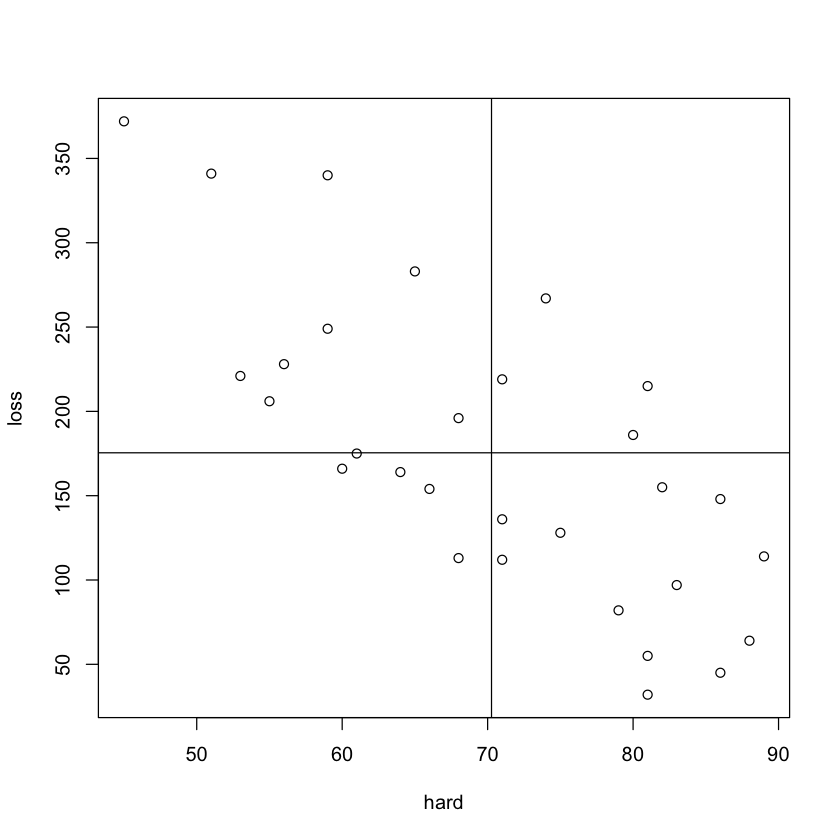

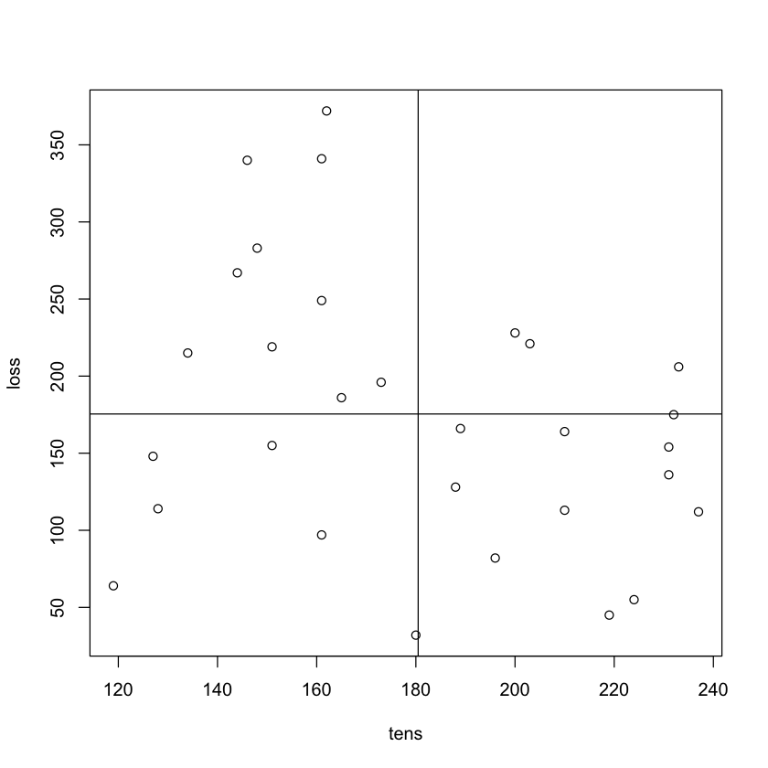

```r
plot(loss~hard); abline(h=mean(loss), v=mean(hard))
plot(loss~tens); abline(h=mean(loss), v=mean(tens))
```

# Estimating and Interpreting Parameters.

**The Basics:**

- There are three model parameters that must be estimated in the linear model $$y=\beta_0+\beta_1x+\varepsilon_y=\beta_0+\beta_1x+\varepsilon$$
- These include the $\beta_0$, $\beta_1$, and $\sigma^2$, the variance of the error term.
- The point estimates for $\beta_0$, $\beta_1$, as expressed by $\hat{\beta_0}$, $\hat{\beta_1s}$ will be used to form the regression line (which is essentially our prediction sequation) $$\hat\mu_{y|x}=\hat\beta_0+\hat\beta_1x$$
- $\hat\mu_{y|x}$ is point estimate for the population $\mu_{y|x}$ mean of the response y at a given value of x
- The most common way to calculate the point estimates $\hat\mu_{y|x}$ is through least-sqaures regression.

**Formulas:**

- $n$ is the sample size and represents the number of (x, y) pairs.
- $\bar{x}$ is the sample mean of the independent (explanatory) variable.
- >$\bar{y}$ is the sample mean of the dependent (response) variable.
- $$SS_{xx}=\sum_{j=1}^n(x_j-\bar x)^2$$ is the sum square deviations in the independent variable.
- $$SS_{yy}=\sum_{j=1}^n(y_j-\bar y)^2$$ is the sum square deviations in the dependent variable.
- $$SS_{xy}=\sum_{j=1}^n(x_j-\bar x)(y_j-\bar y)$$ is the sum of the cross product of the independent and dependent variables.
- The sample variance $\sigma^2$ is calculated by: $$s_x^2=\frac{SS_{xx}}{n-1}$$
- The $\sigma^2$ = $s_x^2$ = $MSE$
- The sample covariance (which measures the strength of the linear relationship between x and y is expressed as $$s_{xy}=\frac{SS_{xy}}{n-1}=\frac1{n-1}\sum_{j=1}^n(x_j-\bar x)(y_j-\bar y)$$.
- $s_{xy}$ can be positive or negative.
- The horizontal deviation is expressed as $x_j-\bar x$ is.
- The vertical deviation is expressed as $y_j-\bar y$ is
- The $SS_{xy}$ is the sum of all the prodcuts of each of the deviations
- The point estimate for the splope is calculated using this formula: $$\hat\beta_1=\frac{SS_{xy}}{SS_{xx}}$$
- $\beta_1$ represents the rate of change of the mean value of the response variable (y) with respect to the explanatory variable (x).
- The point estimate for the intercept is calculated with: $$\hat\beta_0=\bar y-\hat\beta_1\bar x$$.
- The intercept formula implies the regression line with always pass through the center of the data where $(\bar x, \bar y)$
- The $\beta_0$ is generally not key in the interpretation as the linear model is primarily concerned with the range of values in x.
- The following section will demonstrate how to manually calcualte some of these metrics, and R code that does all the heavy lifting.

# Variables

```r
x <- Rubber$hard; x
y <- Rubber$loss; y
n <- length(x); n
```

1. 45

2. 55

3. 61

4. 66

5. 71

6. 71

7. 81

8. 86

9. 53

10. 60

11. 64

12. 68

13. 79

14. 81

15. 56

16. 68

17. 75

18. 83

19. 88

20. 59

21. 71

22. 80

23. 82

24. 89

25. 51

26. 59

27. 65

28. 74

29. 81

30. 86

1. 372

2. 206

3. 175

4. 154

5. 136

6. 112

7. 55

8. 45

9. 221

10. 166

11. 164

12. 113

13. 82

14. 32

15. 228

16. 196

17. 128

18. 97

19. 64

20. 249

21. 219

22. 186

23. 155

24. 114

25. 341

26. 340

27. 283

28. 267

29. 215

30. 148

30

# Calculate $\bar x$ and $\bar y$

```r
xbar <- sum(x)/n ; xbar
ybar <- sum(y)/n ; ybar
```

70.2666666666667

175.433333333333

# Calculate $SS_xx$, $SS_yy$ and $SS_xy$

- You can also use mean(x), mean(y) and var()
- ss.xx = (n-1)*var(x)
- ss.yy = (n-1)*var(y)
- ss.xy = (n-1)*covar(x,y)

```r
SS.xx <- sum( (x-xbar)^2 ); SS.xx
SS.yy <- sum( (y-ybar)^2 ); SS.yy
SS.xy <- sum( (x-xbar)*(y-ybar) ); SS.xy
```

4299.86666666667

225011.366666667

-22946.4666666667

# Calculate the Slope $\hat{\beta_1} = \frac{SS_{xy}}{SS_{xx}}$

```r
b1.hat <- SS.xy/SS.xx; b1.hat
```

-5.33655307141307

# Calculate the Intercept $\hat{\beta_0} = \bar y - \hat \beta_1 \bar x$

```r
b0.hat <- ybar-b1.hat*xbar; b0.hat
```

550.415129151291

# Our regression line (prediction equation)

- $$\hat\mu_{y|x}=\hat\beta_0+\hat\beta_1x$$
- $$\hat\mu_{y|x}=550.415 - 5.3366x$$

# Plot the prediction equation

- Use the R code `abline(a=intercept, b=slope)` to help visualize the results

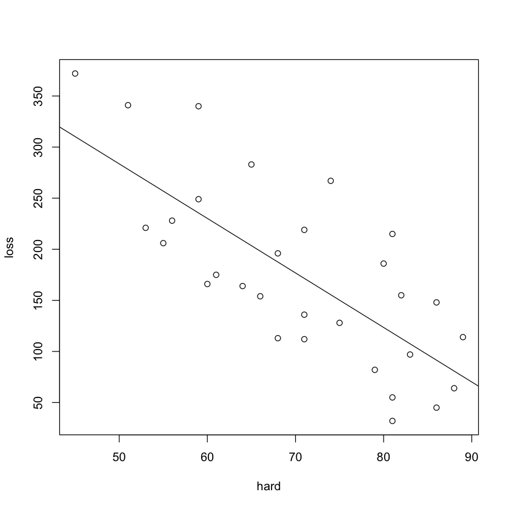

```r
plot(loss~hard)
abline(a=b0.hat, b=b1.hat)
```

# R method to obtain the prediction equation

- name.for.linear.model <-lm(response~independent)
- coefficients( name.for.linear.model )

```r
rubber.lm <- lm(loss~hard)
coefficients(rubber.lm)
```

**(Intercept)**

550.415129151291

**hard**

-5.33655307141306